# Student Performance Analysis

Matteo Staglioli

2026-06-27

This report analyzes the UCI Student Performance dataset, which contains academic and behavioral data on 395 Portuguese high school students. The goal is to explore the relationship between study habits, lifestyle variables, and final grade (G3), using simple and multiple linear regression.

```r
library(tidyverse)
```

```r
stud <- read.csv("student-mat.csv", header = TRUE)
head(stud)
```

```
##   school sex age address famsize Parrent_status Mother_edu Father_edu
## 1     GP   F  18       U     GT3              A          4          4
## 2     GP   F  17       U     GT3              T          1          1
## 3     GP   F  15       U     LE3              T          1          1
## 4     GP   F  15       U     GT3              T          4          2
## 5     GP   F  16       U     GT3              T          3          3
## 6     GP   M  16       U     LE3              T          4          3
##   Mother_job Father_job reason_to_chose_school guardian traveltime
## 1    at_home    teacher                 course   mother          2
## 2    at_home      other                 course   father          1
## 3    at_home      other                  other   mother          1
## 4     health   services                   home   mother          1
## 5      other      other                   home   father          1
## 6   services      other             reputation   mother          1
##   weekly_studytime failures extra_edu_supp family_edu_supp extra_paid_class
```

[output cut: 34 more lines]

For clarity, we use “dim” to count how many columns and rows our dataframe is composed of.

```r
dim(stud)
```

```
## [1] 395  33
```

We want to predict a student’s final score, stored in the “G3” variable, using a simple and a multiple regression model. We will then analyze how these models performed and we will show the differences between them.

For the simple model, we will use “weekly_studytime” as the predictor variable. Let’s see some graphs.

```r
table(stud$weekly_studytime)
```

```
##
##   1   2   3   4
## 105 198  65  27
```

Although weekly_studytime takes only four discrete values, R reads it as an integer. We convert it to a factor so that both the model and visualizations treat it as a categorical variable.

```r
stud$weekly_studytime <- factor(stud$weekly_studytime,
                              levels = 1:4,
                              labels = c("<2 hours", "2–5 hours", "5–10 hours", ">10 hours"))
```

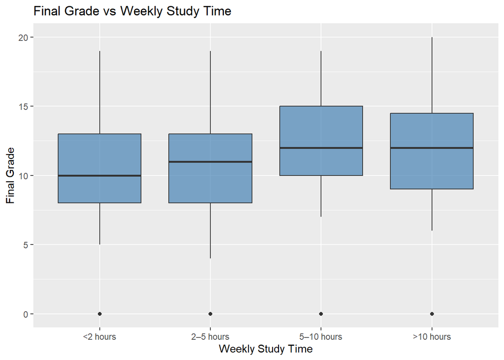

```r
ggplot(data = stud, aes(x = weekly_studytime, y = G3)) +
  geom_boxplot(fill = "steelblue", alpha = 0.7) +
  labs(
    title = "Final Grade vs Weekly Study Time",
    x = "Weekly Study Time",
    y = "Final Grade"
  )
```

The boxplot shows a mild positive trend: median final grade increases from roughly 10 for students studying less than 2 hours up to around 12 for those studying 5 hours or more. However, the >10 hours group shows no further improvement over the 5–10 hours group, suggesting diminishing returns. Outliers at G3 = 0 are present across all categories and likely reflect absences from the final exam rather than actual zero scores.

Let’s proceed by fitting a Simple Linear Model.

```r
lm1 <- lm(G3 ~ weekly_studytime, data = stud)
summary(lm1)
```

```
##
## Call:
## lm(formula = G3 ~ weekly_studytime, data = stud)
##
## Residuals:
##     Min      1Q  Median      3Q     Max
## -11.400  -2.048   0.600   2.828   8.952
##
## Coefficients:
##                            Estimate Std. Error t value Pr(>|t|)
## (Intercept)                 10.0476     0.4459  22.535   <2e-16 ***
## weekly_studytime2–5 hours    0.1241     0.5516   0.225   0.8221
## weekly_studytime5–10 hours   1.3524     0.7211   1.876   0.0615 .
## weekly_studytime>10 hours    1.2116     0.9859   1.229   0.2198
## ---
## Signif. codes:  0 '***' 0.001 '**' 0.01 '*' 0.05 '.' 0.1 ' ' 1
##
## Residual standard error: 4.569 on 391 degrees of freedom
## Multiple R-squared:  0.01308,    Adjusted R-squared:  0.005511
## F-statistic: 1.728 on 3 and 391 DF,  p-value: 0.1607
```

The regression confirms what the boxplot suggested. Students studying 5–10 hours score on average 1.35 points higher than those studying less than 2 hours — the only borderline significant effect (p = 0.06). Beyond that threshold, additional study time yields no further improvement. Overall, weekly study time alone is a poor predictor of final grade (R² = 1.3%, F-test p = 0.16), suggesting that other factors drive most of the variation in G3.

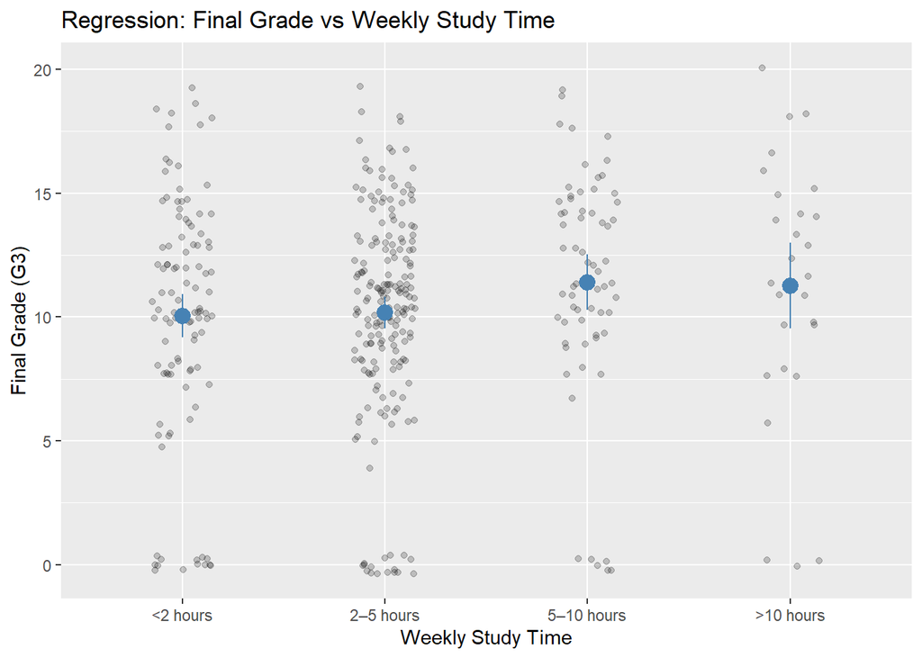

```r
pred <- data.frame(weekly_studytime = levels(stud$weekly_studytime))
pred <- cbind(pred, predict(lm1, newdata = pred, interval = "confidence"))

ggplot() +
  geom_jitter(data = stud, aes(x = weekly_studytime, y = G3),
              alpha = 0.2, width = 0.15) +
  geom_pointrange(data = pred, aes(x = weekly_studytime, y = fit,
                                   ymin = lwr, ymax = upr),
                  color = "steelblue", size = 0.8) +
  labs(title = "Regression: Final Grade vs Weekly Study Time",
       x = "Weekly Study Time",
       y = "Final Grade (G3)")
```

Each dot represents an observed student. The blue points show the model’s predicted mean G3 for each group, with 95% confidence intervals. The wide spread of observations and the heavily overlapping confidence intervals visually confirm the regression results: study time groups differ little in predicted grade, and the uncertainty around each estimate is large relative to the differences between them.

Now, for a more precise analysis, we will try a multiple model. The three additional predictors were chosen based on behavioral and contextual reasoning. “goout_with_friends” and “internet_access” capture lifestyle factors that may compete with or support academic engagement. “absences” is a direct measure of school attendance, which intuitively should relate to final performance. Together, they represent dimensions beyond study time alone — social habits, connectivity, and presence in class.

```r
lm2 <- lm(G3 ~ weekly_studytime + internet_access + absences + goout_with_friends, data = stud)
summary(lm2)
```

```
##
## Call:
## lm(formula = G3 ~ weekly_studytime + internet_access + absences +
##     goout_with_friends, data = stud)
##
## Residuals:
##      Min       1Q   Median       3Q      Max
## -12.4368  -1.9347   0.3767   3.0619   8.9678
##
## Coefficients:
##                            Estimate Std. Error t value Pr(>|t|)
## (Intercept)                10.67369    0.90748  11.762  < 2e-16 ***
## weekly_studytime2–5 hours   0.13824    0.54648   0.253  0.80043
## weekly_studytime5–10 hours  1.13772    0.71944   1.581  0.11460
## weekly_studytime>10 hours   1.13040    0.97816   1.156  0.24854
## internet_accessyes          1.17984    0.61861   1.907  0.05723 .
## absences                    0.02208    0.02879   0.767  0.44368
## goout_with_friends         -0.54715    0.20648  -2.650  0.00838 **
## ---
## Signif. codes:  0 '***' 0.001 '**' 0.01 '*' 0.05 '.' 0.1 ' ' 1
##
## Residual standard error: 4.524 on 388 degrees of freedom
## Multiple R-squared:  0.03957,    Adjusted R-squared:  0.02471
## F-statistic: 2.664 on 6 and 388 DF,  p-value: 0.0152
```

Compared to the simple model, adding three variables improves fit slightly (R² goes from 1.3% to 4%), and the F-test is now significant (p = 0.015) — meaning the model as a whole has some explanatory power, even if modest. The standout finding is goout_with_friends: each unit increase is associated with a 0.55 point decrease in G3 (p = 0.008), the only clearly significant predictor. Internet access shows a borderline positive effect (+1.18 points, p = 0.057). Absences has virtually no effect (p = 0.44), and weekly_studytime remains non-significant across all groups, consistent with the simple model.

Overall, social behavior appears more predictive of final grade than study time in this dataset.

This analysis set out to explain variation in students’ final grades using study time and behavioral variables. The simple model confirmed that weekly study time has a positive but weak and statistically non-significant association with G3 (R² = 1.3%). The multiple model improved fit modestly (R² = 4%), with goout_with_friends emerging as the only clearly significant predictor — each additional unit on the social outing scale is associated with a 0.55 point drop in final grade. Study time remained non-significant even after controlling for other variables. The overall explanatory power of both models remains low, suggesting that final grade is driven by a broader set of factors not captured here — prior academic performance (G1, G2), family background, or school-level effects.